# University of Illinois - Springfield

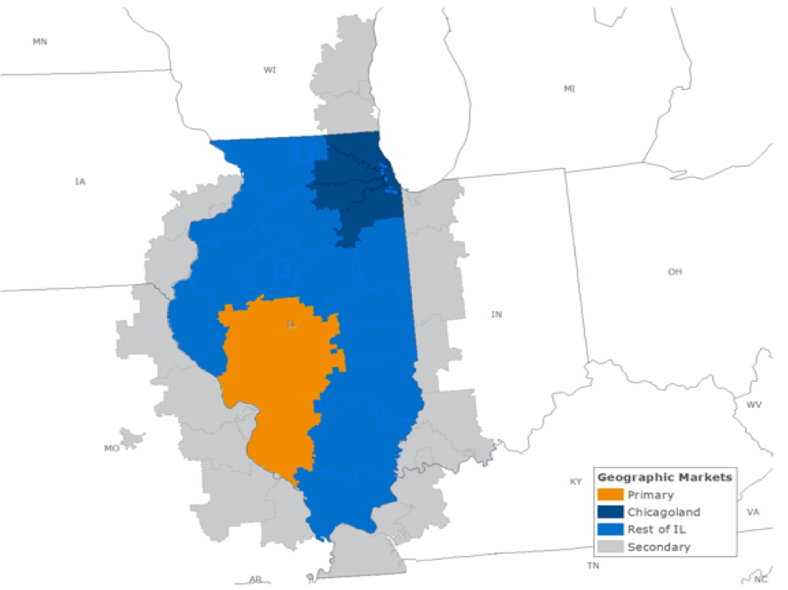

# 1 Primary market purchases (59 orders)

```r
primary_orders
```

```
## # A tibble: 59 x 23
##    univ_id order_num order_title                         created_by      date_updated order_cost num_runs num_students date_start date_end   hs_grad_class zip_code            sat_score_min sat_score_max sat_score_old_min sat_score_old_max psat_score_min psat_score_max psat_score_old_min psat_scor…
##    <chr>   <chr>     <chr>                               <chr>           <date>            <dbl>    <dbl>        <dbl> <date>     <date>     <chr>         <chr>                       <dbl>         <dbl>             <dbl>             <dbl>          <dbl>          <dbl>              <dbl>          …
##  1 148654  440666    SS04 Primary Srs 920-1040 (19) D1   Kathryn Kleeman 2018-12-12         609.        1         1354 2018-12-12 2018-12-12 2019          622|620|627|626|625           920          1040               840               960             NA             NA                 NA          …
##  2 148654  440679    SS03 Primary Srs 1050-1140 (19) D1  Kathryn Kleeman 2018-12-12         340.        1          756 2018-12-12 2018-12-12 2019          622|620|627|626|625          1050          1140               970              1070             NA             NA                 NA          …
##  3 148654  440650    SS02 Primary Srs 1150-12590 (19) D1 Kathryn Kleeman 2018-12-12         281.        1          624 2018-12-12 2018-12-12 2019          622|620|627|626|625          1150          1290              1080              1220             NA             NA                 NA          …
##  4 148654  440649    SS01 Primary Srs 1300-1520 (19) D1  Kathryn Kleeman 2018-12-12         142.        1          316 2018-12-12 2018-12-12 2019          622|620|627|626|625          1300          1520              1230              1490             NA             NA                 NA          …
##  5 148654  444336    P05 Primary Jrs 860-910 (20) JAN    Kathryn Kleeman 2019-01-09         340.        1          755 2019-01-09 2019-01-09 2020          622|620|627|626|625            NA            NA                NA                NA            860            910                 78          …
##  6 148654  444380    P04 Primary Jrs 920-1040 (20) JAN   Kathryn Kleeman 2019-01-09         872.        1         1937 2019-01-09 2019-01-09 2020          622|620|627|626|625            NA            NA                NA                NA            920           1040                 84          …
##  7 148654  444335    P03 Primary Jrs 1050-1140 (20) JAN  Kathryn Kleeman 2019-01-09         552.        1         1226 2019-01-09 2019-01-09 2020          622|620|627|626|625            NA            NA                NA                NA           1050           1140                 97          …
##  8 148654  444349    P02 Primary Jrs 1150-1290 (20) JAN  Kathryn Kleeman 2019-01-09         474.        1         1054 2019-01-09 2019-01-09 2020          622|620|627|626|625            NA            NA                NA                NA           1150           1290                108          …
##  9 148654  444379    P01 Primary Jrs 1300-1520 (20) JAN  Kathryn Kleeman 2019-01-09         169.        1          376 2019-01-09 2019-01-09 2020          622|620|627|626|625            NA            NA                NA                NA           1300           1520                123          …
## 10 148654  444419    P11 Primary Soph 800-850 (21) JAN   Kathryn Kleeman 2019-01-09          27         1           60 2019-01-09 2019-01-09 2021          622|620|627|626|625            NA            NA                NA                NA            800            850                 71          …
## # … with 49 more rows
```

Generally, on each purchase date, they make **4-6 orders by SAT or PSAT score ranges** (**SAT** if purchasing *seniors*, **PSAT** if purchasing *juniors* or *sophomores*):

- **Senior purchases** by **SAT** filter
  - **Dec 2018** (*grad class 2019*): 4 groups (A1, B, C, D)
  - **May 2019** (*grad class 2020*): 4 groups (A1, B, C, D)
  - **Oct 2019** (*grad class 2020*): 5 groups (A2, B, C, D, E)
  - **Mar 2020** (*grad class 2020*): 4 groups (A2, B, C, D)
  - **May 2020** (*grad class 2021*): 4 groups (A2, B, C, D)
- **Junior purchases** by **PSAT** filter
  - **Jan 2019** (*grad class 2020*): 5 groups (B, C, D, E, F)
  - **Oct 2019** (*grad class 2021*): 6 groups (A, B, C, D, E, F)
  - **Jan 2020** (*grad class 2021*): 5 groups (B, C, D, E, F)
- **Sophomore purchases** by **PSAT** filter
  - **Jan 2019** (*grad class 2021*): 6 groups (A, B, C, D, E, F)
  - **Oct 2019** (*grad class 2022*): 5 groups (A, B, C, D, E)
  - **Jan 2020** (*grad class 2022*): 6 groups (A, B, C, D, E, F)
  - **May 2020** (*grad class 2022*): 5 groups (A, C, D, E, F)

```r
# Same for Primary, Chicagoland, and Rest of IL markets
distinct(primary_orders %>% select(sat_score_min, sat_score_max, psat_score_min, psat_score_max)) %>%
  arrange(sat_score_min, psat_score_min) %>%
  add_column(score_range = c('A1', 'A2', 'B', 'C', 'D', 'E', 'A', 'B', 'C', 'D', 'E', 'F'), .before = 1)
```

```
## # A tibble: 12 x 5
##    score_range sat_score_min sat_score_max psat_score_min psat_score_max
##    <chr>               <dbl>         <dbl>          <dbl>          <dbl>
##  1 A1                    920          1040             NA             NA
##  2 A2                    970          1040             NA             NA
##  3 B                    1050          1140             NA             NA
##  4 C                    1150          1290             NA             NA
##  5 D                    1300          1520             NA             NA
##  6 E                    1530          1600             NA             NA
##  7 A                      NA            NA            800            850
##  8 B                      NA            NA            860            910
##  9 C                      NA            NA            920           1040
## 10 D                      NA            NA           1050           1140
## 11 E                      NA            NA           1150           1290
## 12 F                      NA            NA           1300           1520
```

**Common filters**:

- **GPA**: A+ to B-

**General observations**:

- Test score seems to be only differing filter used. Maybe the university doesn’t have access to student-level test scores, so they make separate purchases to be able to identify and target these specific groups?
- Junior and Sophomore purchases both use PSAT score range filters, but Juniors tend to use higher test score ranges (stricter requirement)
- Test score ranges (categories) remain largely unchanged over time, except the minimum score for lowest SAT category increased (A1 to A2)

# 2 Chicagoland market purchases (54 orders)

```r
chicagoland_orders
```

```
## # A tibble: 54 x 24
##    univ_id order_num order_title                            created_by      date_updated order_cost num_runs num_students date_start date_end   hs_grad_class zip_code_file zip_code                    sat_score_min sat_score_max sat_score_old_min sat_score_old_max psat_score_min psat_score_max psa…
##    <chr>   <chr>     <chr>                                  <chr>           <date>            <dbl>    <dbl>        <dbl> <date>     <date>     <chr>         <chr>         <chr>                               <dbl>         <dbl>             <dbl>             <dbl>          <dbl>          <dbl>    …
##  1 148654  440598    SS08 Chicagoland Srs 920-1040 (19) D1  Kathryn Kleeman 2018-12-12        3643.        1         8095 2018-12-12 2018-12-12 2019          NA            601|600|606|605|604|603|602           920          1040               840               960             NA             NA    …
##  2 148654  440654    SS07 Chicagoland Srs 1050-1140 (19) D1 Kathryn Kleeman 2018-12-12        1692         1         3760 2018-12-12 2018-12-12 2019          NA            601|600|606|605|604|603|602          1050          1140               970              1070             NA             NA    …
##  3 148654  440653    SS06 Chicagoland Srs 1150-1290 (19) D1 Kathryn Kleeman 2018-12-12        1664.        1         3698 2018-12-12 2018-12-12 2019          NA            601|600|606|605|604|603|602          1150          1290              1080              1220             NA             NA    …
##  4 148654  440667    SS05 Chicagoland Srs 1300-1520 (19) D1 Kathryn Kleeman 2018-12-12        1809.        1         4019 2018-12-12 2018-12-12 2019          NA            601|600|606|605|604|603|602          1300          1520              1230              1490             NA             NA    …
##  5 148654  444398    P16 Chicagoland Jrs 860-910 (20) JAN   Kathryn Kleeman 2019-01-09        2671.        1         5936 2019-01-09 2019-01-09 2020          NA            601|600|606|605|604|603|602            NA            NA                NA                NA            860            910    …
##  6 148654  444350    P15 Chicagoland Jrs 920-1040 (20) JAN  Kathryn Kleeman 2019-01-09        3105.        1         6899 2019-01-09 2019-01-09 2020          NA            601|600|606|605|604|603|602            NA            NA                NA                NA            920           1040    …
##  7 148654  444382    P14 Chicagoland Jrs 1050-1140 (20) JAN Kathryn Kleeman 2019-01-09        2235.        1         4966 2019-01-09 2019-01-09 2020          NA            601|600|606|605|604|603|602            NA            NA                NA                NA           1050           1140    …
##  8 148654  444381    P13 Chicagoland Jrs 1150-1290 (20) JAN Kathryn Kleeman 2019-01-09        2234.        1         4965 2019-01-09 2019-01-09 2020          NA            601|600|606|605|604|603|602            NA            NA                NA                NA           1150           1290    …
##  9 148654  444397    P12 Chicagoland Jrs 1300-1520 (20) JAN Kathryn Kleeman 2019-01-09        1790.        1         3978 2019-01-09 2019-01-09 2020          NA            601|600|606|605|604|603|602            NA            NA                NA                NA           1300           1520    …
## 10 148654  444418    P22 Chicagoland Soph 800-850 (21) JAN  Kathryn Kleeman 2019-01-09        1248.        1         2774 2019-01-09 2019-01-09 2021          NA            601|600|606|605|604|603|602            NA            NA                NA                NA            800            850    …
## # … with 44 more rows
```

Similarly, on each purchase date, they make **order(s) by SAT or PSAT score ranges** (**SAT** if purchasing *seniors*, **PSAT** if purchasing *juniors* or *sophomores*):

- **Senior purchases** by **SAT** filter
  - **Dec 2018** (*grad class 2019*): 4 groups (A1, B, C, D)
  - **May 2019** (*grad class 2020*): 4 groups (A1, B, C, D)
  - **Oct 2019** (*grad class 2020*): 5 groups (A2, B, C, D, E)
  - **Mar 2020** (*grad class 2020*): 5 groups (A2, B, C, D, E)
  - **May 2020** (*grad class 2021*): 5 groups (A2, B, C, D, E)
- **Junior purchases** by **PSAT** filter
  - **Jan 2019** (*grad class 2020*): 5 groups (B, C, D, E, F)
  - **Oct 2019** (*grad class 2021*): 6 groups (A, B, C, D, E, F)
  - **Jan 2020** (*grad class 2021*): 1 group (B)
- **Sophomore purchases** by **PSAT** filter
  - **Jan 2019** (*grad class 2021*): 6 groups (A, B, C, D, E, F)
  - **Oct 2019** (*grad class 2022*): 6 groups (A, B, C, D, E, F)
  - **Jan 2020** (*grad class 2022*): 1 group (A)
  - **May 2020** (*grad class 2022*): 6 groups (A, B, C, D, E, F)

```r
# Same for Primary, Chicagoland, and Rest of IL markets
distinct(chicagoland_orders %>% select(sat_score_min, sat_score_max, psat_score_min, psat_score_max)) %>%
  arrange(sat_score_min, psat_score_min) %>%
  add_column(score_range = c('A1', 'A2', 'B', 'C', 'D', 'E', 'A', 'B', 'C', 'D', 'E', 'F'), .before = 1)
```

```
## # A tibble: 12 x 5
##    score_range sat_score_min sat_score_max psat_score_min psat_score_max
##    <chr>               <dbl>         <dbl>          <dbl>          <dbl>
##  1 A1                    920          1040             NA             NA
##  2 A2                    970          1040             NA             NA
##  3 B                    1050          1140             NA             NA
##  4 C                    1150          1290             NA             NA
##  5 D                    1300          1520             NA             NA
##  6 E                    1530          1600             NA             NA
##  7 A                      NA            NA            800            850
##  8 B                      NA            NA            860            910
##  9 C                      NA            NA            920           1040
## 10 D                      NA            NA           1050           1140
## 11 E                      NA            NA           1150           1290
## 12 F                      NA            NA           1300           1520
```

**Common filters**:

- **GPA**: A+ to B-

# 3 Rest of IL market purchases (30 orders)

```r
rest_of_IL_orders
```

```
## # A tibble: 30 x 24
##    univ_id order_num order_title                              created_by              date_updated order_cost num_runs num_students date_start date_end   hs_grad_class zip_code_file  zip_code                            sat_score_min sat_score_max sat_score_old_min sat_score_old_max psat_score_min…
##    <chr>   <chr>     <chr>                                    <chr>                   <date>            <dbl>    <dbl>        <dbl> <date>     <date>     <chr>         <chr>          <chr>                                       <dbl>         <dbl>             <dbl>             <dbl>          <dbl>…
##  1 148654  440699    SS12 Rest of IL Srs 920-1040 (19) D1     Kathryn Kleeman         2018-12-12       1726.         1         3836 2018-12-12 2018-12-12 2019          NA             623|610|612|611|614|609|613|608|616           920          1040               840               960             NA…
##  2 148654  440668    SS11 Rest of IL Srs 1050-1140 (19) D1    Kathryn Kleeman         2018-12-12        978.         1         2174 2018-12-12 2018-12-12 2019          NA             623|610|612|611|614|609|613|608|616          1050          1140               970              1070             NA…
##  3 148654  440657    SS10 Rest of IL Srs 1150-1290 (19) D1    Kathryn Kleeman         2018-12-12        786.         1         1747 2018-12-12 2018-12-12 2019          NA             623|610|612|611|614|609|613|608|616          1150          1290              1080              1220             NA…
##  4 148654  440655    SS09 Rest of IL Srs 1300-1520 (19) D1    Kathryn Kleeman         2018-12-12        378          1          840 2018-12-12 2018-12-12 2019          NA             623|610|612|611|614|609|613|608|616          1300          1520              1230              1490             NA…
##  5 148654  473307    SS12 Rest of IL Srs (20) 920-1040 E EAM  Tuonebrandy Tuonepalmer 2019-05-08         50.4        1          112 2019-05-08 2019-05-08 2020          NA             623|610|612|611|614|609|613|608|616           920          1040               840               960             NA…
##  6 148654  473319    SS11 Rest of IL Srs (20) 1050-1140 E EAM Tuonebrandy Tuonepalmer 2019-05-08         48.6        1          108 2019-05-08 2019-05-08 2020          NA             623|610|612|611|614|609|613|608|616          1050          1140               970              1070             NA…
##  7 148654  473306    SS10 Rest of IL Srs (20) 1150-1290 E EAM Tuonebrandy Tuonepalmer 2019-05-08         64.8        1          144 2019-05-08 2019-05-08 2020          NA             623|610|612|611|614|609|613|608|616          1150          1290              1080              1220             NA…
##  8 148654  473318    SS09 Rest of IL Srs (20) 1300-1520 E EAM Tuonebrandy Tuonepalmer 2019-05-08         72          1          160 2019-05-08 2019-05-08 2020          NA             623|610|612|611|614|609|613|608|616          1300          1520              1230              1490             NA…
##  9 148654  511802    SS15 Rest of IL Srs (20) 970-1040 D1     Tuonebrandy Tuonepalmer 2019-10-08       1429.         1         3040 2019-10-08 2019-10-08 2020          Rest of IL.txt NA                                            970          1040               890               960             NA…
## 10 148654  511841    SS14 Rest of IL Srs (20) 1050-1140 D1    Tuonebrandy Tuonepalmer 2019-10-08       1625.         1         3457 2019-10-08 2019-10-08 2020          Rest of IL.txt NA                                           1050          1140               970              1070             NA…
## # … with 20 more rows
```

Similarly, on each purchase date, they make **order(s) by SAT or PSAT score ranges** (**SAT** if purchasing *seniors*, **PSAT** if purchasing *juniors* or *sophomores*):

- **Senior purchases** by **SAT** filter
  - **Dec 2018** (*grad class 2019*): 4 groups (A1, B, C, D)
  - **May 2019** (*grad class 2020*): 4 groups (A1, B, C, D)
  - **Oct 2019** (*grad class 2020*): 5 groups (A2, B, C, D, E)
  - **Mar 2020** (*grad class 2020*): 5 groups (A2, B, C, D, E)
  - **May 2020** (*grad class 2021*): 5 groups (A2, B, C, D, E)
- **Junior purchases** by **PSAT** filter
  - **Oct 2019** (*grad class 2021*): 1 group (A)
- **Sophomore purchases** by **PSAT** filter
  - **May 2020** (*grad class 2022*): 6 groups (A, B, C, D, E, F)

```r
# Same for Primary, Chicagoland, and Rest of IL markets
distinct(rest_of_IL_orders %>% select(sat_score_min, sat_score_max, psat_score_min, psat_score_max)) %>%
  arrange(sat_score_min, psat_score_min) %>%
  add_column(score_range = c('A1', 'A2', 'B', 'C', 'D', 'E', 'A', 'B', 'C', 'D', 'E', 'F'), .before = 1)
```

```
## # A tibble: 12 x 5
##    score_range sat_score_min sat_score_max psat_score_min psat_score_max
##    <chr>               <dbl>         <dbl>          <dbl>          <dbl>
##  1 A1                    920          1040             NA             NA
##  2 A2                    970          1040             NA             NA
##  3 B                    1050          1140             NA             NA
##  4 C                    1150          1290             NA             NA
##  5 D                    1300          1520             NA             NA
##  6 E                    1530          1600             NA             NA
##  7 A                      NA            NA            800            850
##  8 B                      NA            NA            860            910
##  9 C                      NA            NA            920           1040
## 10 D                      NA            NA           1050           1140
## 11 E                      NA            NA           1150           1290
## 12 F                      NA            NA           1300           1520
```

**Common filters**:

- **GPA**: A+ to B-

**General observations**:

- Mostly seniors purchased over juniors/sophomores

# 4 Secondary market purchases (17 orders)

```r
secondary_orders
```

```
## # A tibble: 17 x 24
##    univ_id order_num order_title                             created_by              date_updated order_cost num_runs num_students date_start date_end   hs_grad_class zip_code_file zip_code                            sat_score_min sat_score_max sat_score_old_min sat_score_old_max psat_score_min p…
##    <chr>   <chr>     <chr>                                   <chr>                   <date>            <dbl>    <dbl>        <dbl> <date>     <date>     <chr>         <chr>         <chr>                                       <dbl>         <dbl>             <dbl>             <dbl>          <dbl>  …
##  1 148654  440670    SS14 Sec Srs 1150-1290 (19) E D1        Kathryn Kleeman         2018-12-12       1088.         1         2417 2018-12-12 2018-12-12 2019          NA            637|636|651|633|634|631|476|475|478          1150          1290              1080              1220             NA  …
##  2 148654  440680    SS13 Sec Srs 1300-1400 (19) E D1        Kathryn Kleeman         2018-12-12        475.         1         1055 2018-12-12 2018-12-12 2019          NA            637|636|651|633|634|631|476|475|478          1300          1400              1230              1340             NA  …
##  3 148654  473334    SS14 Secondary Srs (20) 1150-1290 E EAM Tuonebrandy Tuonepalmer 2019-05-08        470.         1         1044 2019-05-08 2019-05-08 2020          NA            637|636|651|633|634|631|476|475|478          1150          1290              1080              1220             NA  …
##  4 148654  473320    SS13 Secondary Srs (20) 1300-1400 E EAM Tuonebrandy Tuonepalmer 2019-05-08        247.         1          549 2019-05-08 2019-05-08 2020          NA            637|636|651|633|634|631|476|475|478          1300          1400              1230              1340             NA  …
##  5 148654  511843    SS21 Secondary Srs (20) 970-1040 E D1   Tuonebrandy Tuonepalmer 2019-10-08        469.         1          998 2019-10-08 2019-10-08 2020          Secondary.txt NA                                            970          1040               890               960             NA  …
##  6 148654  511886    SS20 Secondary Srs (20) 1050-1140 E D1  Tuonebrandy Tuonepalmer 2019-10-08        469.         1          998 2019-10-08 2019-10-08 2020          Secondary.txt NA                                           1050          1140               970              1070             NA  …
##  7 148654  511842    SS19 Secondary Srs (20) 1150-1290 E D1  Tuonebrandy Tuonepalmer 2019-10-08        469.         1          998 2019-10-08 2019-10-08 2020          Secondary.txt NA                                           1150          1290              1080              1220             NA  …
##  8 148654  511885    SS18 Secondary Srs (20) 1300-1400 E D1  Tuonebrandy Tuonepalmer 2019-10-08        187.         1          397 2019-10-08 2019-10-08 2020          Secondary.txt NA                                           1300          1400              1230              1340             NA  …
##  9 148654  511884    SS17 Secondary Srs (20) 1410-1520 E D1  Tuonebrandy Tuonepalmer 2019-10-08        199.         1          423 2019-10-08 2019-10-08 2020          Secondary.txt NA                                           1410          1520              1350              1490             NA  …
## 10 148654  511803    SS16 Secondary Srs (20) 1530-1600 E D1  Tuonebrandy Tuonepalmer 2019-10-08         51.2        1          109 2019-10-08 2019-10-08 2020          Secondary.txt NA                                           1530          1600              1500              1600             NA  …
## 11 148654  515016    P51 Secondary Jrs (21) 800-850 E SEPT   Tuonebrandy Tuonepalmer 2019-10-17        484.         1         1029 2019-10-17 2019-10-17 2021          NA            637|636|651|633|634|631|476|475|478            NA            NA                NA                NA            800  …
## 12 148654  571406    SS21 Secondary Srs (21) 970-1040 E EAM  Tuonebrandy Tuonepalmer 2020-05-11        150.         1          320 2020-05-11 2020-05-11 2021          Secondary.txt NA                                            970          1040               890               960             NA  …
## 13 148654  571405    SS20 Secondary Srs (21) 1050-1140 E EAM Tuonebrandy Tuonepalmer 2020-05-11        262.         1          558 2020-05-11 2020-05-11 2021          Secondary.txt NA                                           1050          1140               970              1070             NA  …
## 14 148654  571366    SS19 Secondary Srs (21) 1150-1290 E EAM Tuonebrandy Tuonepalmer 2020-05-11        370.         1          788 2020-05-11 2020-05-11 2021          Secondary.txt NA                                           1150          1290              1080              1220             NA  …
## 15 148654  571404    SS18 Secondary Srs (21) 1300-1400 E EAM Tuonebrandy Tuonepalmer 2020-05-11        177.         1          377 2020-05-11 2020-05-11 2021          Secondary.txt NA                                           1300          1400              1230              1340             NA  …
## 16 148654  571365    SS17 Secondary Srs (21) 1410-1520 E EAM Tuonebrandy Tuonepalmer 2020-05-11        108.         1          229 2020-05-11 2020-05-11 2021          Secondary.txt NA                                           1410          1520              1350              1490             NA  …
## 17 148654  571363    SS16 Secondary Srs (21) 1530-1600 E EAM Tuonebrandy Tuonepalmer 2020-05-11         18.8        1           40 2020-05-11 2020-05-11 2021          Secondary.txt NA                                           1530          1600              1500              1600             NA  …
```

Similarly, on each purchase date, they make **order(s) by SAT or PSAT score ranges** (**SAT** if purchasing *seniors*, **PSAT** if purchasing *juniors*):

- **Senior purchases** by **SAT** filter
  - **Dec 2018** (*grad class 2019*): 2 groups (C, D)
  - **May 2019** (*grad class 2020*): 2 groups (C, D)
  - **Oct 2019** (*grad class 2020*): 6 groups (A, B, C, D, E, F)
  - **May 2020** (*grad class 2021*): 6 groups (A, B, C, D, E, F)
- **Junior purchases** by **PSAT** filter
  - **Oct 2019** (*grad class 2021*): 1 group (A)

```r
# Higher standards than markets above
distinct(secondary_orders %>% select(sat_score_min, sat_score_max, psat_score_min, psat_score_max)) %>%
  arrange(sat_score_min, psat_score_min) %>%
  add_column(score_range = c('A', 'B', 'C', 'D', 'E', 'F', 'A'), .before = 1)
```

```
## # A tibble: 7 x 5
##   score_range sat_score_min sat_score_max psat_score_min psat_score_max
##   <chr>               <dbl>         <dbl>          <dbl>          <dbl>
## 1 A                     970          1040             NA             NA
## 2 B                    1050          1140             NA             NA
## 3 C                    1150          1290             NA             NA
## 4 D                    1300          1400             NA             NA
## 5 E                    1410          1520             NA             NA
## 6 F                    1530          1600             NA             NA
## 7 A                      NA            NA            800            850
```

**Common filters**:

- **GPA**: A+ to B

**General observations**:

- This market include out-of-state zip codes bordering IL
- Most purchases are for seniors except 1 order for juniors
- Both test score and GPA requirements are stricter for this market than the IL markets

# 5 Other market purchases (28 orders)

```r
other_orders
```

```
## # A tibble: 28 x 22
##    univ_id order_num order_title                 created_by           date_updated order_cost num_runs num_students date_start date_end   hs_grad_class zip_code_file                sat_score_min sat_score_max sat_score_old_min sat_score_old_max psat_score_min psat_score_max psat_score_old_min psa…
##    <chr>   <chr>     <chr>                       <chr>                <date>            <dbl>    <dbl>        <dbl> <date>     <date>     <chr>         <chr>                                <dbl>         <dbl>             <dbl>             <dbl>          <dbl>          <dbl>              <dbl>    …
##  1 148654  355933    RNL 19 ESS M1 GA P1         Elizabeth Villarreal 2017-11-27        224.         1          522 2017-11-27 2017-11-27 2019          UIS M1 Zips - 453.txt                  980          1270               900              1200            900           1190                 82    …
##  2 148654  355963    RNL 19 ESS M2 Apps GA P1    Elizabeth Villarreal 2017-11-27       3049.         1         7090 2017-11-27 2017-11-27 2019          UIS M2 Zips Apps - 137.txt             980          1270               900              1200            900           1190                 82    …
##  3 148654  355932    RNL 19 ESS M1 HA P1         Elizabeth Villarreal 2017-11-27        322.         1          750 2017-11-27 2017-11-27 2019          UIS M1 Zips - 453.txt                 1060          1410               980              1350            980           1330                 90    …
##  4 148654  355962    RNL 19 ESS M2 Apps HA P1    Elizabeth Villarreal 2017-11-27       1465.         1         3406 2017-11-27 2017-11-27 2019          UIS M2 Zips Apps - 137.txt            1060          1410               980              1350            980           1330                 90    …
##  5 148654  372050    RNL 19 ESS M2 No Apps GA P2 Elizabeth Villarreal 2018-02-12         40.0        1           93 2018-02-12 2018-02-12 2019          UIS M2 Zips No Apps - 50.txt           980          1270               900              1200            900           1190                 82    …
##  6 148654  372051    RNL 19 ESS M3 Apps GA P2    Elizabeth Villarreal 2018-02-12       3014.         1         7010 2018-02-12 2018-02-12 2019          UIS M3 Zips Apps - 120.txt             980          1270               900              1200            900           1190                 82    …
##  7 148654  360401    RNL 19 ESS M1 GA P2         Elizabeth Villarreal 2018-02-12        489.         1         1137 2018-02-12 2018-02-12 2019          UIS M1 Zips - 453.txt                  980          1270               900              1200            900           1190                 82    …
##  8 148654  360403    RNL 19 ESS M2 Apps GA P2    Elizabeth Villarreal 2018-02-12       1305.         1         3034 2018-02-12 2018-02-12 2019          UIS M2 Zips Apps - 137.txt             980          1270               900              1200            900           1190                 82    …
##  9 148654  360378    RNL 19 ESS M2 Apps HA P2    Elizabeth Villarreal 2018-02-12        523.         1         1217 2018-02-12 2018-02-12 2019          UIS M2 Zips Apps - 137.txt            1060          1410               980              1350            980           1330                 90    …
## 10 148654  372026    RNL 19 ESS M2 No Apps HA P2 Elizabeth Villarreal 2018-02-12         31.4        1           73 2018-02-12 2018-02-12 2019          UIS M2 Zips No Apps - 50.txt          1060          1410               980              1350            980           1330                 90    …
## # … with 18 more rows
```

**MISSING zip_code_files - CURRENTLY REQUESTING**

**Other filters**:

- **GPA**: A+ to A- **OR** A+ to C